# Final Project — Domain-Appropriate Models for Building Energy Load

Group 5

2026-06-11

```r
pkgs <- c(
  "tidyverse", "caret", "readxl", "ggplot2", "dplyr",
  "kernlab",    # Gaussian Process Regression
  "lightgbm"    # LightGBM gradient boosting
)

lapply(pkgs, library, character.only = TRUE)
```

[output not shown]

```r
img_dir <- "/home/jakes/Documents/strathmore/Modules/Module 3/linear_models/classwork/final_project/markdowns/images"
dir.create(img_dir, showWarnings = FALSE, recursive = TRUE)
```

# 1 Why These Models?

The models in the previous nonlinear analysis — Random Forest, XGBoost, SVM, Neural Network, and the rest — are general-purpose algorithms. They work on almost any tabular dataset without needing to “know” anything about what the data represents. That is both their strength and their limitation.

The ENB2012 dataset is different from a typical tabular prediction problem. It was generated by EnergyPlus, a thermodynamic simulator, using the physics of heat transfer through building envelopes. The relationship between building geometry and energy load is not arbitrary — it follows physical laws. A building with more glazing loses more heat. A more compact building (lower surface-to- volume ratio) loses less. A taller building with the same footprint behaves differently than a shorter one.

This creates two opportunities. First, we can use models that are well-suited to small, structured, simulation-generated datasets — models that can extract more information from 768 rows than a general-purpose learner can. Second, we can validate our models not just by their test-set error, but by checking whether their predictions respect the physical logic of the problem.

This file introduces three models chosen for these reasons:

- **Gaussian Process Regression with an RBF kernel** — a Bayesian model that treats the entire dataset as a probability distribution over functions and is particularly suited to surrogate modelling of simulation outputs.
- **Gaussian Process Regression with a Matérn 5/2 kernel** — a variant that makes slightly different assumptions about how smoothly building geometry translates into energy load, allowing us to compare kernel choices systematically.
- **LightGBM** — a modern gradient boosting algorithm that handles the discrete, categorical-like structure of this dataset’s features more efficiently than XGBoost, and is the current standard in applied machine learning on tabular data.

We close with a physics-consistency check: a diagnostic that asks whether the model’s predictions agree with what the heat transfer equation tells us they should be, independent of measured error.

# 2 Load Data

```r
df <- read_excel(
  "~/Documents/strathmore/Modules/Module 3/linear_models/classwork/final_project/markdowns/new_data/ENB2012_post_EDA.xlsx"
)

cat("Rows:", nrow(df), "\n")
```

```
## Rows: 768
```

```r
cat("Columns:", paste(names(df), collapse = ", "), "\n")
```

```
## Columns: RelCompactness, SurfaceArea, WallArea, RoofArea, OverallHeight, Orientation, GlazingArea, GlazingAreaDist, HeatingLoad, CoolingLoad, Orientation_f, OverallHeight_f, GlazingArea_f, GlazingAreaDist_f, is_outlier
```

# 3 Restore Factor Variables

When the post-EDA file is saved to Excel and reloaded, R’s factor types are lost. We restore them here from the underlying numeric columns before doing anything else. This matters because some models and all diagnostic plots depend on these levels being correctly defined.

```r
df$Orientation_f <- factor(df$Orientation, levels = 2:5,
                            labels = c("N", "E", "S", "W"))

df$OverallHeight_f <- factor(df$OverallHeight, levels = c(3.5, 7.0),
                              labels = c("Low_3.5m", "High_7m"))

df$GlazingArea_f <- factor(df$GlazingArea, levels = c(0, 0.1, 0.25, 0.4),
                            labels = c("None", "Low_10pct", "Med_25pct",
                                       "High_40pct"))

df$GlazingAreaDist_f <- factor(df$GlazingAreaDist, levels = 0:5,
                                labels = c("None", "Uniform", "N_heavy",
                                           "E_heavy", "S_heavy", "W_heavy"))

cat("Factor levels confirmed:\n")
```

```
## Factor levels confirmed:
```

```r
cat("  Orientation_f    :", levels(df$Orientation_f), "\n")
```

```
##   Orientation_f    : N E S W
```

```r
cat("  OverallHeight_f  :", levels(df$OverallHeight_f), "\n")
```

```
##   OverallHeight_f  : Low_3.5m High_7m
```

```r
cat("  GlazingArea_f    :", levels(df$GlazingArea_f), "\n")
```

```
##   GlazingArea_f    : None Low_10pct Med_25pct High_40pct
```

```r
cat("  GlazingAreaDist_f:", levels(df$GlazingAreaDist_f), "\n")
```

```
##   GlazingAreaDist_f: None Uniform N_heavy E_heavy S_heavy W_heavy
```

# 4 Feature Engineering

We reproduce the same engineered features from the main nonlinear file. These are all physically motivated — they are products, ratios, or squares of the original building geometry variables that correspond to quantities that appear directly in heat transfer calculations.

For example, `CompactnessXHeight` approximates the shape factor that determines how much surface area a building exposes relative to its enclosed volume and height. `WallXGlazing` captures the interaction between the amount of exposed wall and the proportion of that wall made of glass — two factors that jointly determine conductive heat loss. `SurfToVol` is the surface-to- volume ratio, which is the single most important geometric determinant of a building’s thermal efficiency.

None of these features use the target variable (HeatingLoad or CoolingLoad) at any point in their construction, so building them before the train/test split is safe — they cannot introduce leakage.

```r
df_clean <- df %>%
  mutate(
    CompactnessXHeight  = RelCompactness * OverallHeight,
    WallToRoofRatio     = WallArea / RoofArea,
    GlazingXCompactness = GlazingArea * RelCompactness,
    SurfToVol           = SurfaceArea / (WallArea + RoofArea),
    GlazingXHeight      = GlazingArea * OverallHeight,
    WallXGlazing        = WallArea * GlazingArea,
    CompactnessSquared  = RelCompactness^2,
    HeightSquared       = OverallHeight^2,
    GlazingToWall       = GlazingArea / (WallArea + 1),
    EnvelopeArea        = WallArea + RoofArea,
    WallPerHeight       = WallArea / (OverallHeight + 1)
  )

cat("Feature engineering complete. Total columns:", ncol(df_clean), "\n")
```

```
## Feature engineering complete. Total columns: 26
```

# 5 The Group Key and Why It Matters

The dataset has a structure that is easy to miss on first inspection. The 768 rows are not 768 independent buildings. They are 192 unique building configurations, each simulated under four compass orientations (North, East, South, West). So every building in the data has three orientation-siblings — rows that are identical in every physical respect except which way the building faces.

Orientation turns out to have very little effect on heating or cooling load in this simulation, which makes sense physically: compass orientation shifts where solar gain enters the building but does not change the total envelope area, compactness, or insulation. The within-group variation in HeatingLoad due to orientation is less than 7% of the overall standard deviation.

The practical consequence for modelling is this: if a naive random split sends one orientation variant of a building to training and another to the test set, the model does not need to generalise — it just recognises the building configuration and copies the answer from the training row. This inflates test metrics without reflecting genuine predictive ability.

We prevent this by splitting at the **group level**: all four orientation variants of every building configuration are placed entirely in training or entirely in test. This is the methodologically honest evaluation.

```r
df_clean <- df_clean %>%
  mutate(
    group_key = paste(RelCompactness, WallArea, RoofArea,
                      OverallHeight, GlazingArea, GlazingAreaDist, sep = "_")
  )

cat("Total rows            :", nrow(df_clean), "\n")
```

```
## Total rows            : 768
```

```r
cat("Unique building groups:", length(unique(df_clean$group_key)), "\n")
```

```
## Unique building groups: 192
```

```r
cat("Rows per group        :", nrow(df_clean) / length(unique(df_clean$group_key)), "\n")
```

```
## Rows per group        : 4
```

# 6 Train / Test Split

With the group key in place, we split the 192 building configurations approximately 80/20 into training and test. About 154 configurations (~616 rows) go to training; the remaining ~38 configurations (~152 rows) become the test set. Zero group overlap is verified before proceeding — any non-zero value here would mean the split failed.

```r
set.seed(42)
unique_groups  <- unique(df_clean$group_key)
n_train_groups <- round(0.80 * length(unique_groups))
train_groups   <- sample(unique_groups, n_train_groups)

df_train <- df_clean %>% filter( group_key %in% train_groups)
df_test  <- df_clean %>% filter(!group_key %in% train_groups)

group_overlap <- length(intersect(df_train$group_key, df_test$group_key))
cat("Training rows :", nrow(df_train), "\n")
```

```
## Training rows : 616
```

```r
cat("Test rows     :", nrow(df_test),  "\n")
```

```
## Test rows     : 152
```

```r
cat("Group overlap :", group_overlap,
    ifelse(group_overlap == 0, "  <- zero leakage confirmed\n",
                               "  <- WARNING: leakage present\n"))
```

```
## Group overlap : 0   <- zero leakage confirmed
```

# 7 The Feature Set

We define the model feature set once here and reuse it for every model below. Two variables from the original dataset are intentionally excluded:

- **SurfaceArea** is dropped because it equals `WallArea + 2 × RoofArea` exactly for all 768 rows. Including it alongside WallArea and RoofArea would give any model three variables where only two carry independent information, creating perfect collinearity that destabilises coefficient estimates and inflates apparent feature importance.
- **Orientation** is dropped because, as established above, it contributes less than 7% of within-group variance in the target and acts as noise rather than signal.

```r
features <- c(
  "RelCompactness", "WallArea", "RoofArea",
  "OverallHeight", "GlazingArea", "GlazingAreaDist",
  "CompactnessXHeight", "WallToRoofRatio", "GlazingXCompactness",
  "SurfToVol", "GlazingXHeight", "WallXGlazing",
  "CompactnessSquared", "GlazingToWall", "EnvelopeArea", "WallPerHeight"
)

cat("Feature set (", length(features), "predictors):\n", sep = "")
```

```
## Feature set (16predictors):
```

```r
cat(paste(" -", features), sep = "\n")
```

```
##  - RelCompactness
##  - WallArea
##  - RoofArea
##  - OverallHeight
##  - GlazingArea
##  - GlazingAreaDist
##  - CompactnessXHeight
##  - WallToRoofRatio
##  - GlazingXCompactness
##  - SurfToVol
##  - GlazingXHeight
##  - WallXGlazing
##  - CompactnessSquared
##  - GlazingToWall
##  - EnvelopeArea
##  - WallPerHeight
```

# 8 Feature Scaling

GPR and LightGBM have different relationships with feature scaling, and it is worth being explicit about this.

GPR is sensitive to scale. The kernel function measures distances between data points in feature space to determine how similar they are. If one feature has values in the thousands (like WallArea) and another has values between 0 and 1 (like GlazingArea), the kernel will be almost entirely dominated by WallArea — not because WallArea is more important, but simply because it has larger numbers. Standardising all features to mean zero and standard deviation one removes this numerical imbalance and allows the kernel to compare features on an equal footing.

LightGBM, like all tree-based models, is completely unaffected by monotone transformations of the feature values. A tree splits on a threshold, and whether that threshold is 294 or 0.2 (after scaling) makes no difference to the tree structure. We scale anyway for consistency, so that all three models are trained on identical inputs and their results are directly comparable.

Scaling is fitted **only on the training set** and then applied to the test set using the training set’s parameters. Fitting the scaler on the combined data would leak information about the test set’s distribution into training, which is a subtle but real form of data leakage.

```r
scale_cols <- features  # scale all model features

preproc_params <- caret::preProcess(
  df_train[, scale_cols],
  method = c("center", "scale")
)

df_train[, scale_cols] <- predict(preproc_params, df_train[, scale_cols])
df_test[, scale_cols]  <- predict(preproc_params, df_test[, scale_cols])

cat("Scaling complete. Fitted on training set only.\n")
```

```
## Scaling complete. Fitted on training set only.
```

```r
# Spot check: training features should now have mean ≈ 0 and sd ≈ 1
check <- df_train %>%
  dplyr::select(all_of(scale_cols[1:4])) %>%
  summarise(across(everything(),
    list(mean = ~round(mean(.), 3), sd = ~round(sd(.), 3))))
cat("Spot check (mean should be ~0, sd should be ~1):\n")
```

```
## Spot check (mean should be ~0, sd should be ~1):
```

```r
print(check)
```

```
## # A tibble: 1 × 8
##   RelCompactness_mean RelCompactness_sd WallArea_mean WallArea_sd RoofArea_mean
##                 <dbl>             <dbl>         <dbl>       <dbl>         <dbl>
## 1                   0                 1             0           1             0
## # ℹ 3 more variables: RoofArea_sd <dbl>, OverallHeight_mean <dbl>,
## #   OverallHeight_sd <dbl>
```

# 9 Cross-Validation Setup

For hyperparameter tuning inside `caret::train()` we use group-aware cross-validation. Standard k-fold cross-validation assigns rows to folds randomly, which causes the same orientation-sibling problem we fixed in the train/test split: a building configuration can end up on both sides of a fold boundary. Group k-fold forces each fold boundary to fall between building configurations, never within one. This gives CV metric estimates that reflect genuine out-of-group generalisation.

```r
set.seed(42)
group_folds <- caret::groupKFold(df_train$group_key, k = 5)

ctrl_grp <- trainControl(
  method          = "cv",
  index           = group_folds,
  savePredictions = "final",
  verboseIter     = FALSE
)

cat("Group-aware 5-fold CV control ready.\n")
```

```
## Group-aware 5-fold CV control ready.
```

```r
cat("Each fold boundary falls between building configurations,\n")
```

```
## Each fold boundary falls between building configurations,
```

```r
cat("not within them. Orientation siblings cannot span a fold.\n")
```

```
## not within them. Orientation siblings cannot span a fold.
```

# 10 Evaluation Helper

A small function that takes the actual and predicted values and computes three metrics. RMSE and MAE are in the same units as the target (kWh/m²), making them directly interpretable: “the model’s predictions are off by X kWh/m² on average.” R² captures the proportion of variance explained and allows comparison with published benchmarks on this dataset.

```r
eval_reg <- function(actual, predicted, model_name) {
  rmse <- sqrt(mean((actual - predicted)^2))
  mae  <- mean(abs(actual - predicted))
  r2   <- 1 - sum((actual - predicted)^2) / sum((actual - mean(actual))^2)
  cat(sprintf("%-35s  RMSE=%.4f  MAE=%.4f  R²=%.4f\n",
              model_name, rmse, mae, r2))
  data.frame(Model = model_name, RMSE = rmse, MAE = mae, R2 = r2)
}

results_y1 <- data.frame()
results_y2 <- data.frame()
```

# 11 Gaussian Process Regression — Background

Before running the models it is worth explaining what Gaussian Process Regression actually does, because it works differently from every other model in this project.

Most models — linear regression, random forests, neural networks — learn a single function that maps inputs to outputs. They give you one number as the prediction. GPR instead learns a **distribution over functions**. Rather than committing to a single mapping from building geometry to energy load, it maintains uncertainty about that mapping and represents it explicitly.

The way it does this is through a **kernel function**. The kernel defines how similar two buildings are to each other in terms of their feature vectors. Buildings that are geometrically similar (high kernel similarity) are assumed to have similar energy loads. Buildings that are geometrically different (low kernel similarity) are assumed to be largely independent in their load values. GPR uses this similarity structure across all training buildings to produce, for any new building, both a predicted load value and a confidence interval around that prediction.

For ENB2012 specifically, GPR has a very natural interpretation: each row is a point in a 16-dimensional feature space (our 16 predictors), and we are using the known outputs at 616 of those points to infer the output at the remaining 152. The kernel controls how the information from each training point “radiates outward” to nearby regions of that space.

We fit two versions of GPR, each using a different kernel. The kernel choice embeds assumptions about the physical system, and comparing them tells us something about the nature of the geometry-to-load relationship.

## 11.1 Model A — GPR with the RBF Kernel

### 11.1.1 What the RBF kernel assumes

The Radial Basis Function (RBF) kernel — also called the squared exponential or Gaussian kernel — is the most commonly used kernel in GPR. It assumes that the function being learned is **infinitely smooth**: buildings that differ slightly in geometry will differ only slightly in energy load, and the relationship between geometry and load has no abrupt jumps or kinks anywhere.

In mathematical terms, the RBF kernel between two feature vectors x and x’ is:

k(x, x’) = σ² × exp(−||x − x’||² / 2ℓ²)

where σ² is the overall signal variance (how much the output varies across the input space) and ℓ is the length-scale (how far apart two buildings need to be before their loads are considered unrelated). Both parameters are estimated from the training data by maximising the marginal likelihood — meaning the data itself determines what “similar” means.

### 11.1.2 Why this is a reasonable assumption for ENB2012

Building heat transfer is governed by physical equations that are continuous and smooth. A building with a compactness of 0.80 should have a load that is very close to one with a compactness of 0.79. There are no sudden phase transitions or threshold effects in the physics. The RBF kernel’s smoothness assumption therefore aligns well with the underlying simulation logic.

### 11.1.3 Y1 — Heating Load

```r
# ── GPR with RBF kernel — Heating Load ────────────────────────────────────────
# gausspr() from kernlab fits a Gaussian Process on the training data.
# kpar = "automatic" instructs kernlab to estimate the kernel length-scale
# by maximising the marginal likelihood of the training data — this is
# the principled, data-driven way to set the kernel hyperparameter and
# avoids having to choose it by hand.

set.seed(42)
gpr_rbf_y1 <- gausspr(
  x      = as.matrix(df_train[, features]),
  y      = df_train$HeatingLoad,
  kernel = "rbfdot",
  kpar   = "automatic",
  var    = 0.01   # noise variance — small because ENB2012 is a clean simulation
)
```

```
## Using automatic sigma estimation (sigest) for RBF or laplace kernel
```

```r
cat("=== GPR (RBF) — Heating Load ===\n")
```

```
## === GPR (RBF) — Heating Load ===
```

```r
print(gpr_rbf_y1)
```

```
## Gaussian Processes object of class "gausspr"
## Problem type: regression
##
## Gaussian Radial Basis kernel function.
##  Hyperparameter : sigma =  0.0819666141081652
##
## Number of training instances learned : 616
## Train error : 0.002812208
```

```r
pred_gpr_rbf_y1 <- predict(gpr_rbf_y1,
                            newdata = as.matrix(df_test[, features]))

results_y1 <- rbind(results_y1,
  eval_reg(df_test$HeatingLoad, pred_gpr_rbf_y1, "GPR (RBF)"))
```

```
## GPR (RBF)                            RMSE=1.1234  MAE=0.8147  R²=0.9874
```

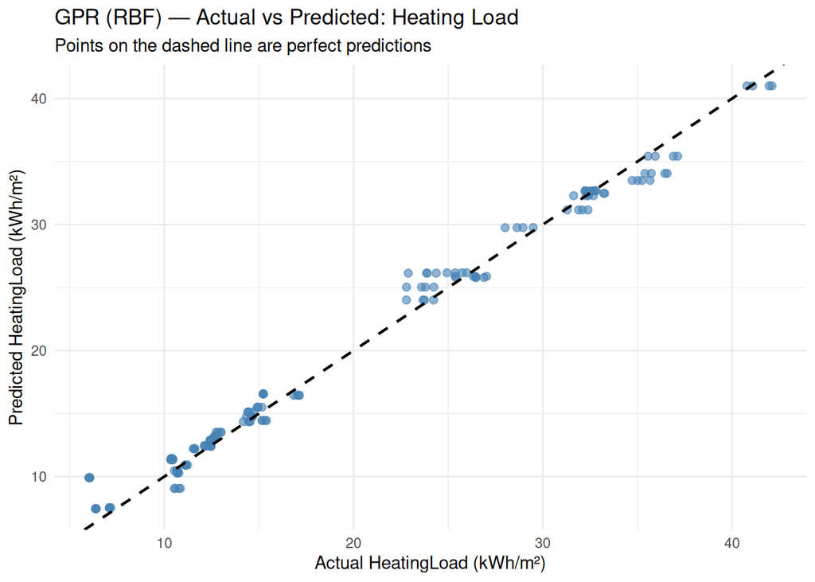

```r
# Actual vs predicted plot
gpr_rbf_y1_df <- data.frame(
  Actual    = df_test$HeatingLoad,
  Predicted = as.vector(pred_gpr_rbf_y1),
  Residual  = df_test$HeatingLoad - as.vector(pred_gpr_rbf_y1)
)

p_gpr_rbf_y1 <- ggplot(gpr_rbf_y1_df, aes(x = Actual, y = Predicted)) +
  geom_point(alpha = 0.6, colour = "steelblue", size = 2) +
  geom_abline(slope = 1, intercept = 0, colour = "black",
              linetype = "dashed", linewidth = 0.8) +
  labs(title    = "GPR (RBF) — Actual vs Predicted: Heating Load",
       subtitle = "Points on the dashed line are perfect predictions",
       x = "Actual HeatingLoad (kWh/m²)",
       y = "Predicted HeatingLoad (kWh/m²)") +
  theme_minimal()

ggsave(file.path(img_dir, "gpr_rbf_y1_actual_vs_pred.png"),
       plot = p_gpr_rbf_y1, width = 8, height = 6, dpi = 150)
print(p_gpr_rbf_y1)
```

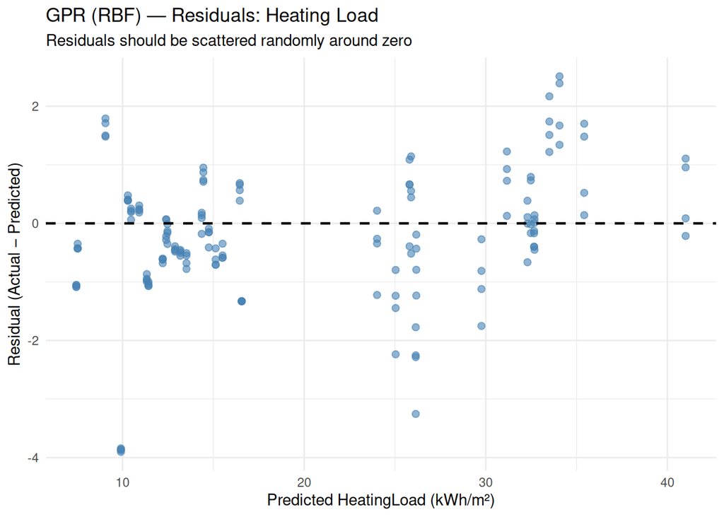

```r
# Residual plot
p_gpr_rbf_y1_resid <- ggplot(gpr_rbf_y1_df, aes(x = Predicted, y = Residual)) +
  geom_point(alpha = 0.6, colour = "steelblue", size = 2) +
  geom_hline(yintercept = 0, colour = "black",
             linetype = "dashed", linewidth = 0.8) +
  labs(title    = "GPR (RBF) — Residuals: Heating Load",
       subtitle = "Residuals should be scattered randomly around zero",
       x = "Predicted HeatingLoad (kWh/m²)",
       y = "Residual (Actual − Predicted)") +
  theme_minimal()

ggsave(file.path(img_dir, "gpr_rbf_y1_residuals.png"),
       plot = p_gpr_rbf_y1_resid, width = 8, height = 6, dpi = 150)
print(p_gpr_rbf_y1_resid)
```

### 11.1.4 Y2 — Cooling Load

```r
# ── GPR with RBF kernel — Cooling Load ────────────────────────────────────────
# Same setup as Y1. The model is refit from scratch on CoolingLoad — we do
# not reuse the Y1 model object. Each target gets its own trained GPR.

set.seed(42)
gpr_rbf_y2 <- gausspr(
  x      = as.matrix(df_train[, features]),
  y      = df_train$CoolingLoad,
  kernel = "rbfdot",
  kpar   = "automatic",
  var    = 0.01
)
```

```
## Using automatic sigma estimation (sigest) for RBF or laplace kernel
```

```r
cat("=== GPR (RBF) — Cooling Load ===\n")
```

```
## === GPR (RBF) — Cooling Load ===
```

```r
print(gpr_rbf_y2)
```

```
## Gaussian Processes object of class "gausspr"
## Problem type: regression
##
## Gaussian Radial Basis kernel function.
##  Hyperparameter : sigma =  0.0819666141081652
##
## Number of training instances learned : 616
## Train error : 0.029603967
```

```r
pred_gpr_rbf_y2 <- predict(gpr_rbf_y2,
                            newdata = as.matrix(df_test[, features]))

results_y2 <- rbind(results_y2,
  eval_reg(df_test$CoolingLoad, pred_gpr_rbf_y2, "GPR (RBF)"))
```

```
## GPR (RBF)                            RMSE=2.0260  MAE=1.5027  R²=0.9520
```

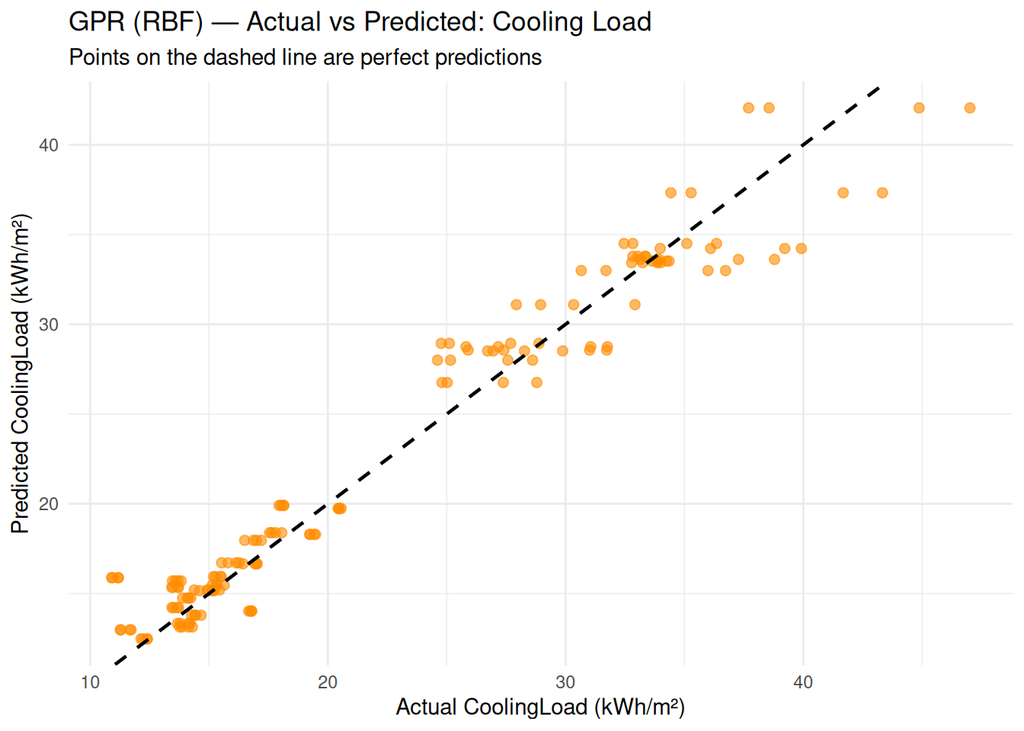

```r
# Actual vs predicted plot
gpr_rbf_y2_df <- data.frame(
  Actual    = df_test$CoolingLoad,
  Predicted = as.vector(pred_gpr_rbf_y2),
  Residual  = df_test$CoolingLoad - as.vector(pred_gpr_rbf_y2)
)

p_gpr_rbf_y2 <- ggplot(gpr_rbf_y2_df, aes(x = Actual, y = Predicted)) +
  geom_point(alpha = 0.6, colour = "darkorange", size = 2) +
  geom_abline(slope = 1, intercept = 0, colour = "black",
              linetype = "dashed", linewidth = 0.8) +
  labs(title    = "GPR (RBF) — Actual vs Predicted: Cooling Load",
       subtitle = "Points on the dashed line are perfect predictions",
       x = "Actual CoolingLoad (kWh/m²)",
       y = "Predicted CoolingLoad (kWh/m²)") +
  theme_minimal()

ggsave(file.path(img_dir, "gpr_rbf_y2_actual_vs_pred.png"),
       plot = p_gpr_rbf_y2, width = 8, height = 6, dpi = 150)
print(p_gpr_rbf_y2)
```

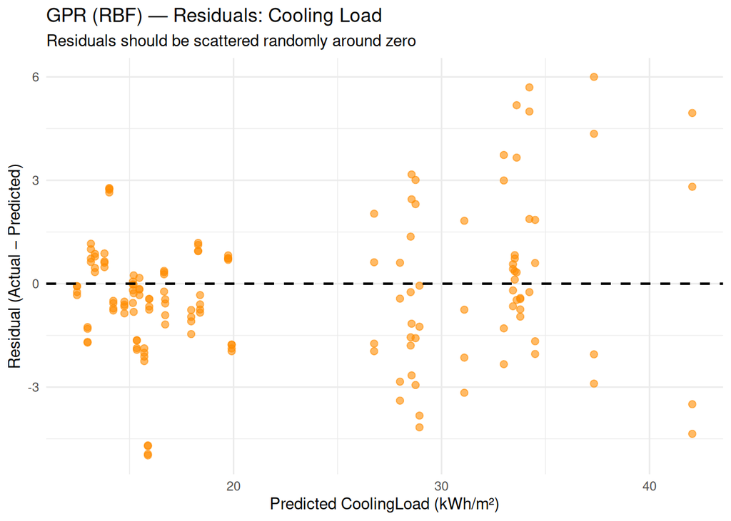

```r
p_gpr_rbf_y2_resid <- ggplot(gpr_rbf_y2_df, aes(x = Predicted, y = Residual)) +
  geom_point(alpha = 0.6, colour = "darkorange", size = 2) +
  geom_hline(yintercept = 0, colour = "black",
             linetype = "dashed", linewidth = 0.8) +
  labs(title    = "GPR (RBF) — Residuals: Cooling Load",
       subtitle = "Residuals should be scattered randomly around zero",
       x = "Predicted CoolingLoad (kWh/m²)",
       y = "Residual (Actual − Predicted)") +
  theme_minimal()

ggsave(file.path(img_dir, "gpr_rbf_y2_residuals.png"),
       plot = p_gpr_rbf_y2_resid, width = 8, height = 6, dpi = 150)
print(p_gpr_rbf_y2_resid)
```